# Programming with Data Mid-term Coursework

```python
active_mcr_by_year_df['Mean'] = active_mcr_by_year_df.iloc[:, 1:-1].mean(axis=1)
# finding mean value of crime rates for each year

active_mcr_by_year_df.head()
```

|  | 0 | 1 | 2 | 3 | 4 | 5 | 6 | 7 | 8 | 9 | ... | 44 | 45 | 46 | 47 | 48 | 49 | 50 | 51 | 52 | Mean |
| --- | --- | --- | --- | --- | --- | --- | --- | --- | --- | --- | --- | --- | --- | --- | --- | --- | --- | --- | --- | --- | --- |
| 2009 | 22.3 | NaN | NaN | 99.2 | NaN | NaN | NaN | NaN | NaN | 56.7 | ... | 104.5 | 143.4 | 101.8 | NaN | NaN | 167.5 | NaN | 30.6 | 426 | 254.806667 |
| 2010 | NaN | 119.2 | NaN | 96.3 | 105.2 | 34.1 | NaN | NaN | 213.6 | NaN | ... | 116.1 | 139.7 | 102.2 | NaN | NaN | NaN | NaN | 53.6 | 420.6 | 223.047500 |
| 2011 | NaN | NaN | NaN | 95.7 | NaN | NaN | NaN | 78.1 | NaN | 56.6 | ... | 81.7 | 129.4 | 99.4 | NaN | 56.5 | 173.3 | 109.8 | 43.6 | 389.3 | 238.938235 |
| 2012 | NaN | 119.8 | NaN | 101.9 | 128.9 | NaN | NaN | NaN | 50.7 | NaN | ... | 95.4 | NaN | 91.4 | NaN | NaN | NaN | 107.5 | NaN | 306.3 | 228.775000 |
| 2013 | 27.8 | NaN | NaN | 110.9 | 126.6 | NaN | NaN | NaN | 84.3 | 51.5 | ... | 93.9 | 82.2 | 91.2 | NaN | 49.2 | 156.4 | 108.3 | 55.7 | 302.1 | 205.118919 |

5 rows × 54 columns

### Split dataframe to get data of countries with abolished death penalty

```python
abolished_mcr_by_year = new_correlation_table[new_correlation_table['Status'].isin(['abolished in practice'])]
# create new dataframe with countries that have abolished capital punishment

abolished_mcr_by_year.index = range(21)

abolished_mcr_by_year.head()
```

|  | Country | 2009 | 2010 | 2011 | 2012 | 2013 | 2014 | 2015 | 2016 | 2017 | 2018 | Status |
| --- | --- | --- | --- | --- | --- | --- | --- | --- | --- | --- | --- | --- |
| 0 | Kenya | 117.7 | 114.6 | 118.3 | 100.4 | 117.4 | 114.6 | 113.3 | 98.9 | 101.6 | 101.6 | abolished in practice |
| 1 | Malawi | NaN | 80.3 | NaN | 79.5 | NaN | 74.6 | 72.4 | 81.5 | 83.7 | 76.8 | abolished in practice |
| 2 | Zambia | 117.6 | 122.5 | NaN | 117.5 | 114 | 111.4 | 116.9 | 116.1 | 148.3 | NaN | abolished in practice |
| 3 | Cameroon | 118.1 | 116.8 | 109.1 | 106.5 | 114.7 | 114.2 | 120.7 | 122.6 | 129.6 | NaN | abolished in practice |
| 4 | Central African Republic | 49.4 | NaN | 19.1 | NaN | NaN | NaN | 17 | NaN | NaN | NaN | abolished in practice |

### Clean dataframe to only include crime rates over the years for all countries with abolished death penalty

```python
abolished_mcr_by_year_df = abolished_mcr_by_year.transpose()
# switching row and column to easily find average of the new rows

abolished_mcr_by_year_df = abolished_mcr_by_year_df.drop(index = abolished_mcr_by_year_df.index[0], axis=1)
# dropping the first row

abolished_mcr_by_year_df = abolished_mcr_by_year_df.drop(index = abolished_mcr_by_year_df.index[-1], axis=1)
# dropping the last row

abolished_mcr_by_year_df.head()
```

|  | 0 | 1 | 2 | 3 | 4 | 5 | 6 | 7 | 8 | 9 | ... | 11 | 12 | 13 | 14 | 15 | 16 | 17 | 18 | 19 | 20 |
| --- | --- | --- | --- | --- | --- | --- | --- | --- | --- | --- | --- | --- | --- | --- | --- | --- | --- | --- | --- | --- | --- |
| 2009 | 117.7 | NaN | 117.6 | 118.1 | 49.4 | NaN | 180.3 | 250 | 256.7 | NaN | ... | 46 | NaN | 43.4 | NaN | 385.8 | NaN | NaN | 134.9 | NaN | NaN |
| 2010 | 114.6 | 80.3 | 122.5 | 116.8 | NaN | 136.2 | 200.6 | NaN | NaN | 54.5 | ... | NaN | 48.7 | 32.4 | 34.9 | 413.2 | 123.8 | 226.8 | 128.4 | 58.4 | 152.9 |
| 2011 | 118.3 | NaN | NaN | 109.1 | 19.1 | 136.4 | NaN | 195.5 | 351.1 | NaN | ... | 37.5 | NaN | 44.7 | NaN | 427.1 | NaN | NaN | 113.8 | NaN | NaN |
| 2012 | 100.4 | 79.5 | 117.5 | 106.5 | NaN | 134 | 212.6 | NaN | 316.1 | 51.9 | ... | NaN | 43.2 | 38.8 | 41.1 | 457 | NaN | 250.4 | 113.1 | 45.4 | 153.4 |
| 2013 | 117.4 | NaN | 114 | 114.7 | NaN | 157.9 | 213.5 | 228.2 | 301.7 | 52.7 | ... | 30.2 | NaN | 43.6 | 47.8 | 444.4 | NaN | NaN | 130.7 | NaN | NaN |

5 rows × 21 columns

```python
abolished_mcr_by_year_df['Mean'] = abolished_mcr_by_year_df.iloc[:, 1:-1].mean(axis=1)
# finding mean value of crime rates for each year

abolished_mcr_by_year_df.head()
```

|  | 0 | 1 | 2 | 3 | 4 | 5 | 6 | 7 | 8 | 9 | ... | 12 | 13 | 14 | 15 | 16 | 17 | 18 | 19 | 20 | Mean |
| --- | --- | --- | --- | --- | --- | --- | --- | --- | --- | --- | --- | --- | --- | --- | --- | --- | --- | --- | --- | --- | --- |
| 2009 | 117.7 | NaN | 117.6 | 118.1 | 49.4 | NaN | 180.3 | 250 | 256.7 | NaN | ... | NaN | 43.4 | NaN | 385.8 | NaN | NaN | 134.9 | NaN | NaN | 147.272727 |
| 2010 | 114.6 | 80.3 | 122.5 | 116.8 | NaN | 136.2 | 200.6 | NaN | NaN | 54.5 | ... | 48.7 | 32.4 | 34.9 | 413.2 | 123.8 | 226.8 | 128.4 | 58.4 | 152.9 | 126.964286 |
| 2011 | 118.3 | NaN | NaN | 109.1 | 19.1 | 136.4 | NaN | 195.5 | 351.1 | NaN | ... | NaN | 44.7 | NaN | 427.1 | NaN | NaN | 113.8 | NaN | NaN | 147.420000 |
| 2012 | 100.4 | 79.5 | 117.5 | 106.5 | NaN | 134 | 212.6 | NaN | 316.1 | 51.9 | ... | 43.2 | 38.8 | 41.1 | 457 | NaN | 250.4 | 113.1 | 45.4 | 153.4 | 143.364286 |
| 2013 | 117.4 | NaN | 114 | 114.7 | NaN | 157.9 | 213.5 | 228.2 | 301.7 | 52.7 | ... | NaN | 43.6 | 47.8 | 444.4 | NaN | NaN | 130.7 | NaN | NaN | 147.876923 |

5 rows × 22 columns

### Plotting a line graph

It shows the average crime rates over the years for active and abolish capital punishment respectively.

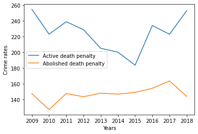

```python
plt.plot(active_mcr_by_year_df["Mean"], label="Active death penalty")
plt.plot(abolished_mcr_by_year_df["Mean"], label="Abolished death penalty")
# plot individual lines

plt.legend()
plt.xlabel("Years")
plt.ylabel("Crime rates")
# creating a legend

plt.show()
# display plot
```

## Step 6: Conclusion based on second analysis

From the second analysis, we have divided the dataset into two dataframes - one with active death penalties in place and another with abolished death penalties as an average for each year, to observe any trends over the year. Unfortunately, from the line graph above, it is difficult to discern any sort of overall increase or decrease in the trend over the years. For the active death penalty, crime rates were dropping from the years 2009 to 2015 before increasing to its original level in 2018. FOr countries with abolished death penalty, crime rates show a slight increase across the years to 2017, before dropping in 2018. Since there is no discernable trend, this still agrees with my hypothesis that there is no correlation between implementing capital punishment and lower crime rates, as crime rates remain to be increasing and decreasing at a similar rate constantly.

However, even though there is no clear conclusion on the impact the death penalty has on the trend on crime rates across the years, it can be clearly seen that in the decade, countries with active death penalty has consistently higher crime rates compared to countries with the abolished death penalty.

Hence, we can draw the conclusions that active capital punishment does indeed results in more countries with higher crime rates and abolishing the capital punishment results in more countries with lower crime rates. Hence, this not only agrees with my hypothesis that there is no correlation between implementing capital punishment and lower crime rates, it also goes beyond to suggest that capital punishment is indeed ineffective in reducing crime.

### Problems/biasness within the dataset

One of the key features of the dataset that might have been problematic is that data is skewed towards the subset of data for countries with active capital punishment. This is because after cleaning the data and splitting the dataset into two new data frames - one for active capital punishment and another for abolished capital punishment, I realised that there are 53 sets of data for the first and 21 for the latter. Hence, there might be an over-representation of data from the former such that when finding average crime rates for both data frames, the latter becomes much less accurate in comparison to the first. Hence this is a potential bias in the dataset as 71% of the dataset falls into the active capital punishment demographic and 29% for the other, making it less ideal for comparison between the two datsets.

## Step 7: Overall conclusion

In conclusion, both analysis have proved my hypothesis correct, that there is no correlation between implenting capital punishment and lower crime rates. In fact, they went beyond to show that countries with abolished capital punishment have comparatively lower crime rates than the former. This suggests that capital punishment is indeed ineffective in reducing crime hence the effectiveness of moving towards instating a restorative justice system over a retributive one.

## Ethics of use of data

The description of where the data has come from has been already been explained when introducing both datasets.

### Considerations about usage/reusage of data

The analysis confirms a new form of intellectual property, which is that the capital punishment is ineffective in reducing crime. This data should be used by all countries if possible, as it aims to reduce crime rates across the world, and promote a better standard of living for the people, as well as increase productivity for the country.

### Consideration around implications of utilising data for purpose

There is no power to discriminate as it aims to promote healthy social behaviour towards all crime offendors, especially ex-crime offenders, as it is vital to welcome them back and reinstate them into society such that they can once again contribute back to society and the economy positively.

However, one dangerous or harmful assumption is that countries might not take enough measures to rehabilitate criminals before releasing them, thinking that abolishing the capital punishment will reduce crime rates. Hence, I emphasize that such countries should take a further step beyond to focus on implementing a rehabilitative justice system that these successful countries have adopted, rather than just abolishing capital punishment.

### Considerations of the data processing pipeline

The data is readily accessible in my notebook and fully anonymised.

### Any potential biases of the dataset

Potential biasedness has been considered in the analysis and conclusion sections.

Report completed by: Student ID 190488303